# Covid-19 Colombia

Martin Olarte

4/28/2020

### Información sobre las Estadísticas

**Fuentes**: Johns Hopkins University, WHO, CDC, ECDC, NHC, DXY, 1point3acres, Worldometers.info, BNO, the COVID Tracking Project (para pruebas y hospitalizaciones), departamentos de salud estatales y nacionales, y reportajes de medios de comunicación locales. Más información aquí. Para información detallada de la información en Colombia se usaron los reportes diarios del [Instituto Nacional de Salud](https://www.ins.gov.co/Noticias/Paginas/Coronavirus.aspx).

- A partir del 14 de abril, los casos confirmados incluyen presuntos casos positivos y casos probables, de acuerdo con las [pautas](https://www.cdc.gov/coronavirus/2019-ncov/cases-updates/cases-in-us.html) de los Centros de Control y Prevención de Enfermedades de Estados Unidos (CDC).
- A partir del 14 de abril, los totales de muertes en los Estados Unidos incluyen confirmados y probables, de acuerdo con las [pautas](https://www.cdc.gov/coronavirus/2019-ncov/cases-updates/cases-in-us.html) de los CDC.
- Los casos recuperados fuera de China son estimaciones basadas en informes de medios de comunicación locales y en informes estatales y locales cuando están disponibles, y por lo tanto pueden ser sustancialmente más bajos que el número real.

### Gráficas Importantes

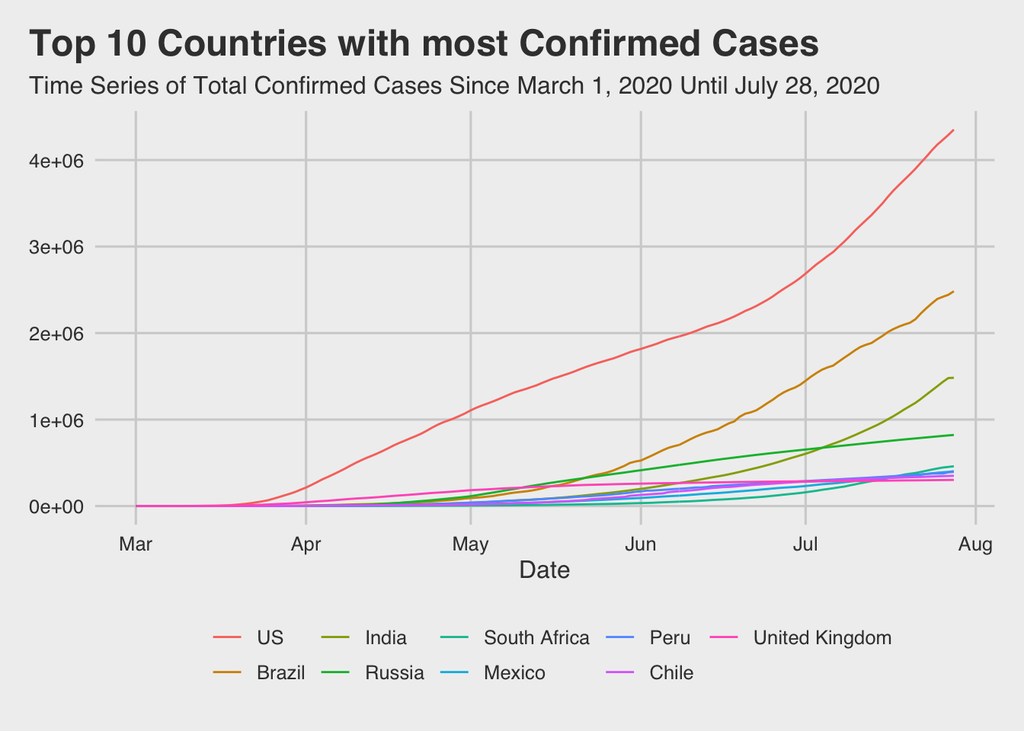

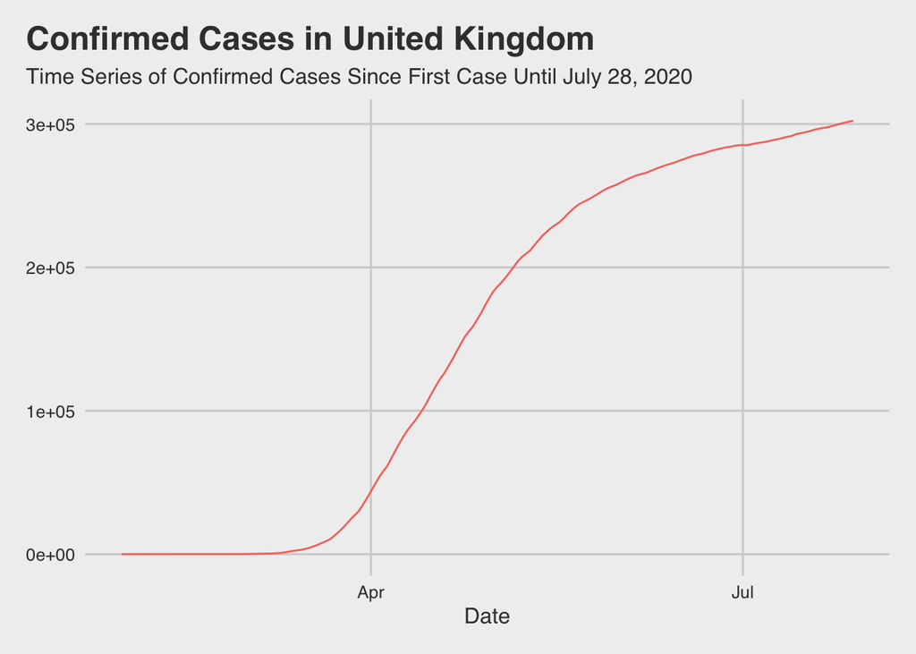

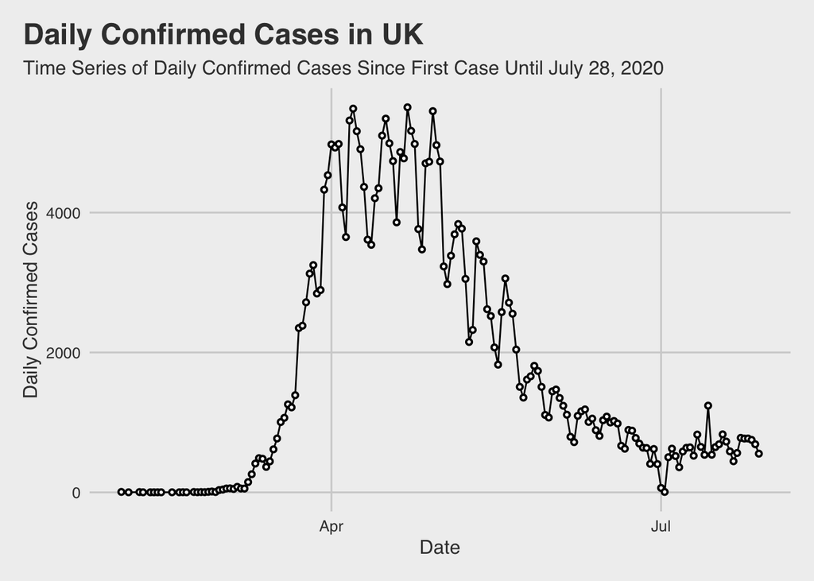

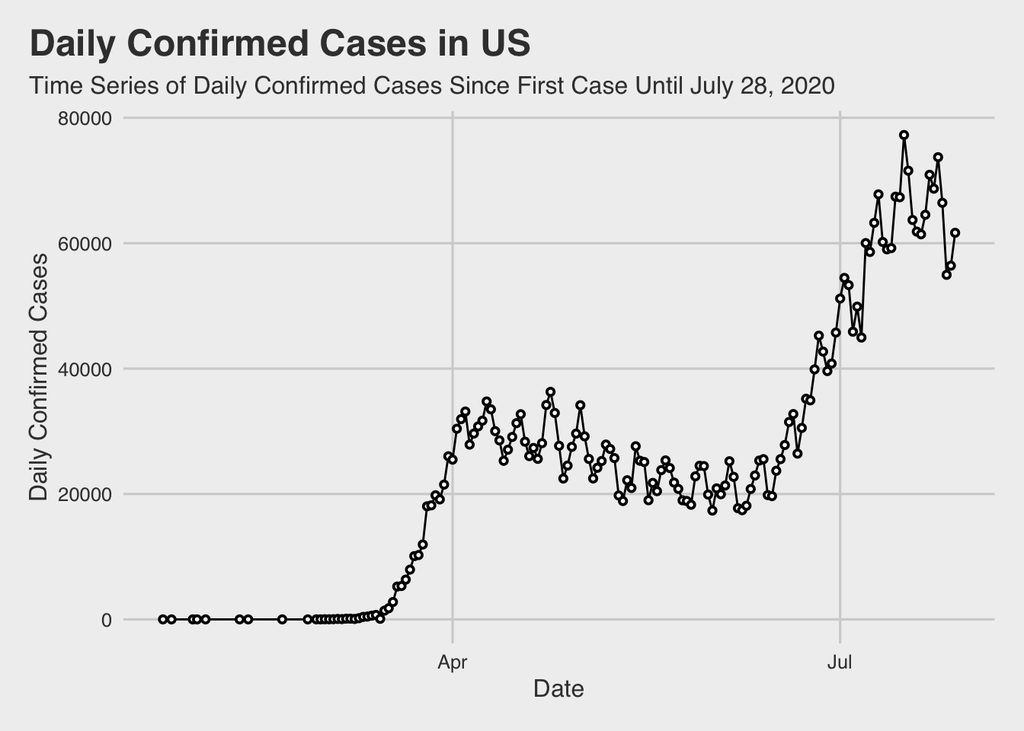

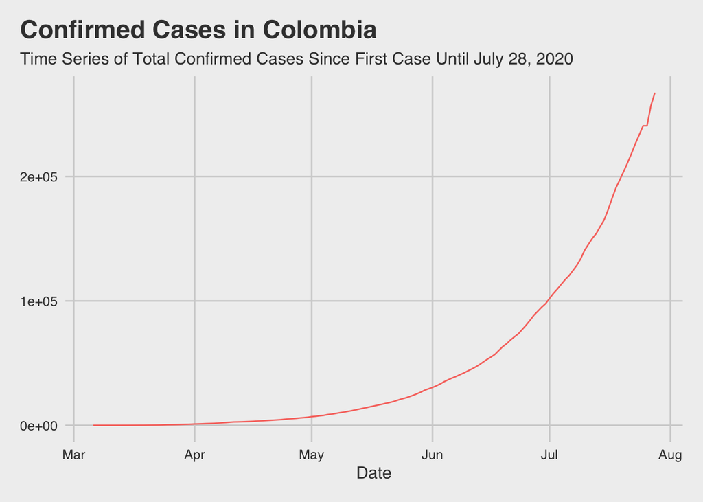

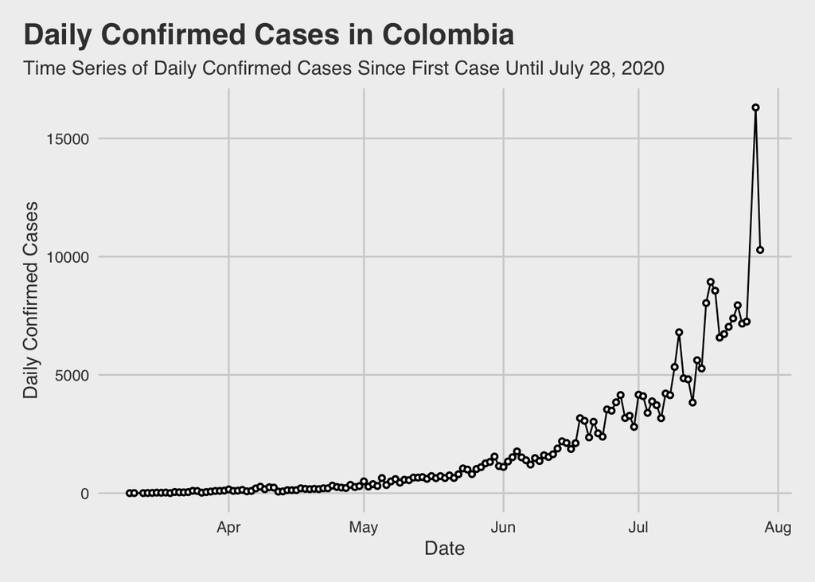

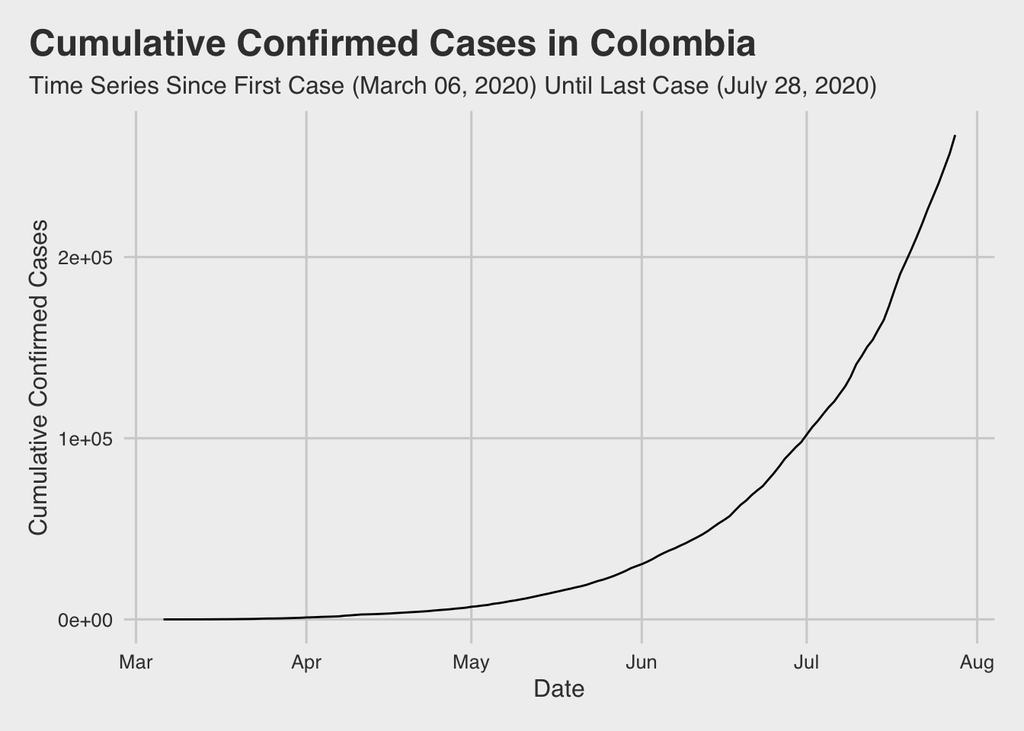

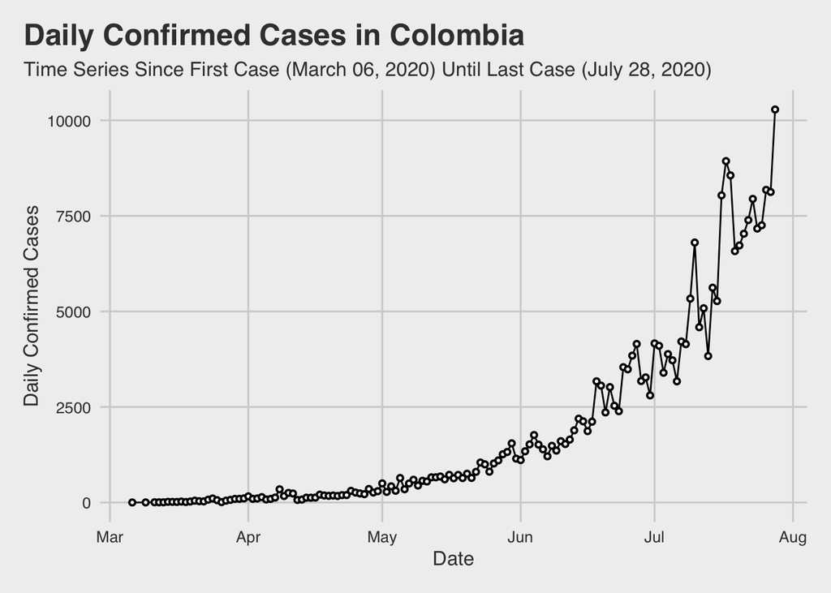

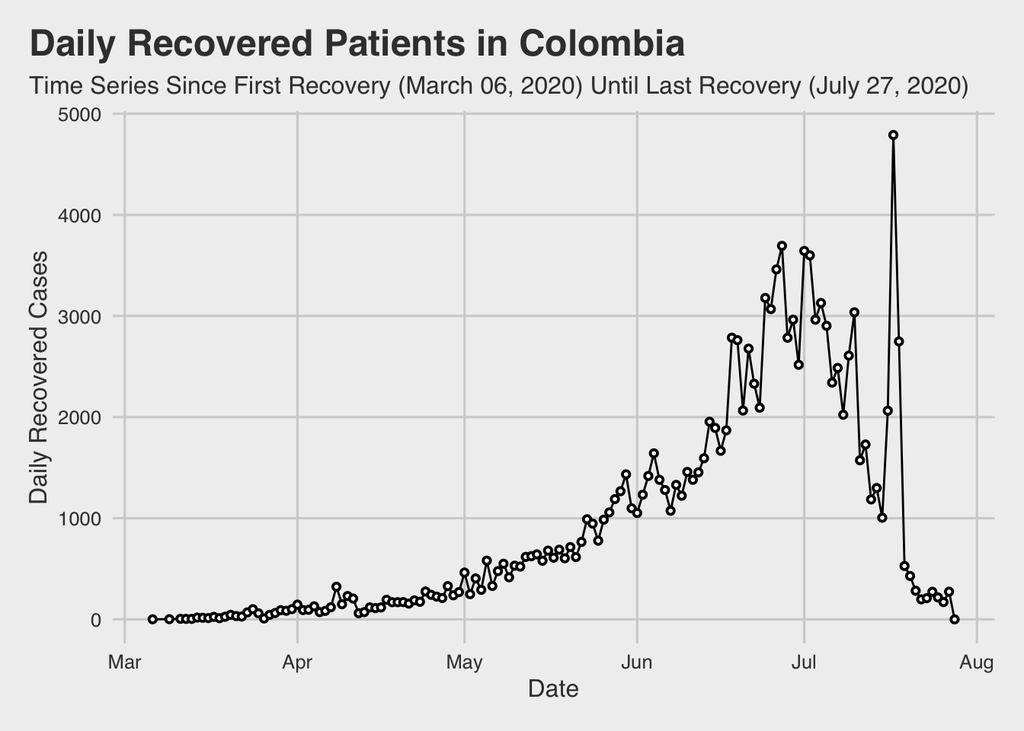

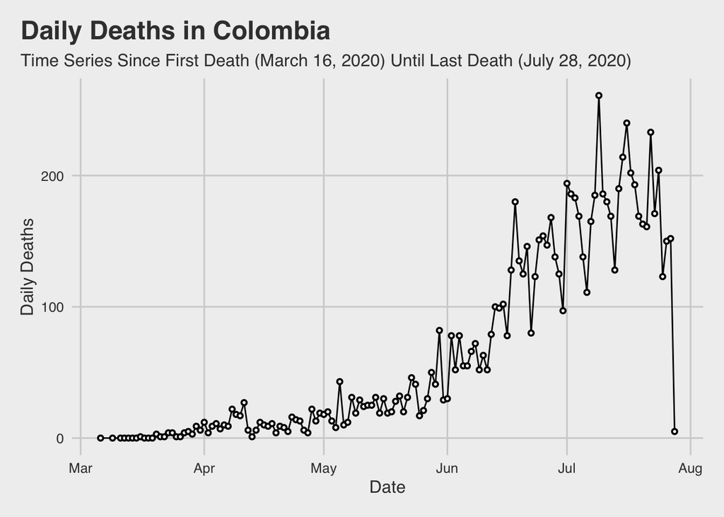

$\text{Casos Activos en EEUU}$ **(2,847,378)** $= \text{Confirmados}$ **(4,351,997)** $- \text{ Recuperados}$ **(1,355,363)** $- \text{ Muertes}$ **(149,256)**

$\text{Tasa de Incidencia en EEUU} = \frac{\text{Confirmados}}{1.000.000 \text{ de habitantes}} =$ **13,214**

$\text{Tasa de Letalidad de Casos Confirmados en EEUU (%)} = \frac{\text{Número de muertes registradas}}{\text{ Número de casos confirmados}}\times 100 =$ **3.43**

$\text{Muestras Procesadas por Millon de Habitantes en EEUU} = \frac{\text{Número de muestras procesadas}}{1.000.000 \text{ de habitantes}} =$ **61,337**  
$\text{Casos Activos en Colombia}$ **(121,621)** $= \text{Confirmados}$ **(267,385)** $- \text{ Recuperados}$ **(136,690)** $- \text{ Muertes}$ **(9,074)**

$\text{Tasa de Incidencia en Colombia} = \frac{\text{Confirmados}}{1.000.000 \text{ de habitantes}} =$ **5,308**

$\text{Tasa de Letalidad de Casos Confirmados en Colombia (%)} = \frac{\text{Número de muertes registradas}}{\text{ Número de casos confirmados}}\times 100 =$ **3.39**

$\text{Muestras Procesadas por Millon de Habitantes en Colombia} = \frac{\text{Número de muestras procesadas}}{1.000.000 \text{ de habitantes}} =$ **29,195**

```
## # A tibble: 91 x 16
##    `ID DE CASO` `FECHA REPORTE … `FECHA DE NOTIF… ATENCION  EDAD SEXO  TIPO
##           <dbl> <date>           <date>           <chr>    <dbl> <chr> <chr>
##  1          130 2020-03-20       2020-03-18       Recuper…    53 M     Impo…
##  2          356 2020-03-24       2020-03-21       Recuper…    32 M     Impo…
##  3        29988 2020-06-01       2020-05-23       Recuper…    38 F     Rela…
##  4        29989 2020-06-01       2020-05-25       Recuper…    41 M     Rela…
##  5        29990 2020-06-01       2020-05-23       Recuper…    46 F     Rela…
##  6        29991 2020-06-01       2020-05-23       Recuper…    65 F     Rela…
##  7        29992 2020-06-01       2020-05-23       Recuper…    41 F     Rela…
##  8        29993 2020-06-01       2020-05-23       Recuper…    52 M     Rela…
##  9        29994 2020-06-01       2020-05-23       Recuper…    52 F     Rela…
## 10        29995 2020-06-01       2020-05-23       Recuper…    37 M     Rela…
## # … with 81 more rows, and 9 more variables: ESTADO <chr>, `PAIS DE
## #   PROCEDENCIA` <chr>, `FECHA DE MUERTE` <date>, `FECHA DIAGNOSTICO` <date>,
## #   `FECHA RECUPERADO` <date>, `TIPO RECUPERACION` <chr>, `PERTENENCIA
## #   ETNICA` <chr>, `NOMBRE GRUPO ETNICO` <chr>, case_num <int>
```

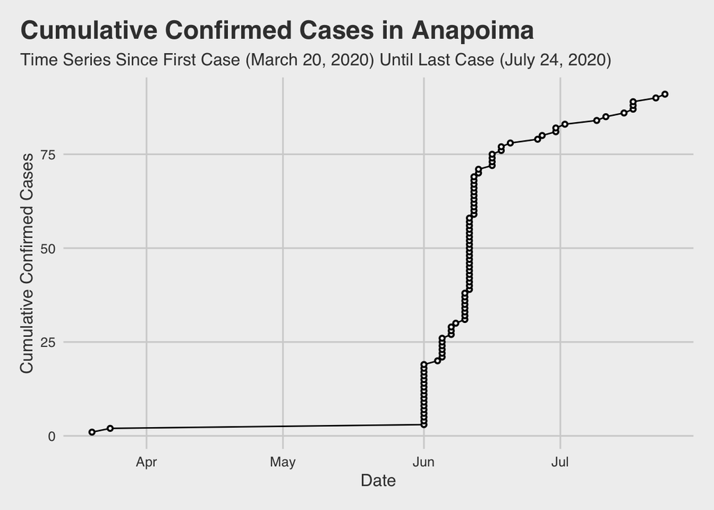

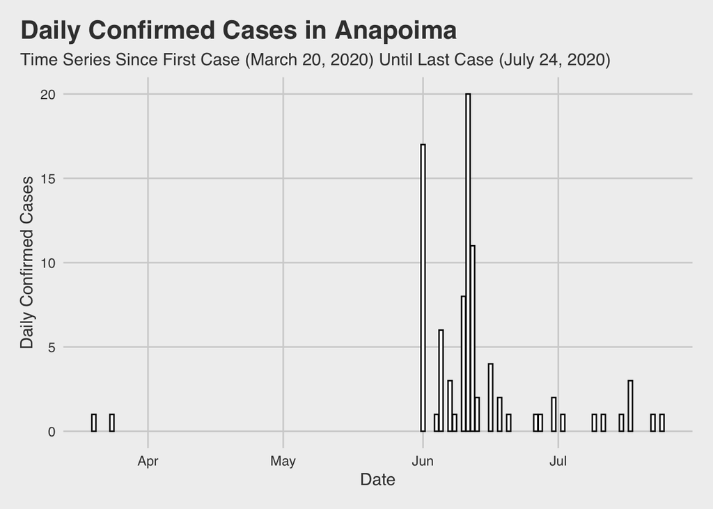